# Notebooks with "dashboard" / split cell layouts

**Authors:** Gena Gibson

## Intro

It's remarkably difficult to get a true dashboard layout without creating a full web app - something which significantly increases the cost and complexity of any project. As a workaround, I have made some custom template files that allow for cell splitting within the notebook. This enables graphs and tables to be displayed side by side.

It is not as flexible as a full dashboard capability, but it should be sufficient for many projects.

**Before you start, check that you have pulled down the latest version of the repository:**  
Update your version of the GitHub repository: https://github.com/genagibson/ricardo_template_style  
It has various files in that you'll need to copy.

## Enable splitting cells

We can use the Split Cell Notebook extension to enable splitting cells 50:50 in the notebook.

- First, ensure that you have nbextensions enabled. If you don't, follow the instructions in the guidelines to set up your template
- Enable `Split Cells Notebook` Extension
- A new icon will appear, as shown in the picture below. Click it to split any code cell in the notebook and have them aligned side by side.

Location of split cells toggle

[figure not shown]

And now it's very easy to layout cells side by side simply by toggling that button - just like so!

Some nice interactive plot

[interactive chart not shown]

Some table

|  | sepal_length | sepal_width |
| --- | --- | --- |
| 0 | 5.1 | 3.5 |
| 1 | 4.9 | 3 |
| 2 | 4.7 | 3.2 |
| 3 | 4.6 | 3.1 |
| 4 | 5 | 3.6 |

Some other plot

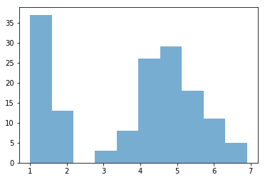

We can also have markdown in split cell format

See, we can have markdown...

... In split cell format

## Exporting

Unfortunately, that's not the end of the story. The standard extension only works in the Notebook view. If you try to export it, you will find that the cells just return to the usual report layout. The way to fix this is by applying a custom template file.

There are a few steps, but it's a one-time only setup.

### Copy custom template files

First, we need to find the folder in which your jupyter extensions are saved. Run the following command:

```python
!pip show jupyter_contrib_nbextensions
```

```
Name: jupyter-contrib-nbextensions
Version: 0.5.1
Summary: A collection of Jupyter nbextensions.
Home-page: https://github.com/ipython-contrib/jupyter_contrib_nbextensions.git
Author: ipython-contrib and jupyter-contrib developers
Author-email: jupytercontrib@gmail.com
License: BSD
Location: c:\users\gg6\appdata\local\continuum\anaconda3\lib\site-packages
Requires: lxml, notebook, jupyter-latex-envs, jupyter-core, pyyaml, jupyter-contrib-core, jupyter-nbextensions-configurator, traitlets, ipython-genutils, nbconvert, tornado, jupyter-highlight-selected-word
Required-by:
```

Look at the path under "location", and add '\jupyter_contrib_nbextensions\templates' to it (on Windows. Use forward slashes on a Mac)

For example, mine is at:

```
c:\users\gg6\appdata\local\continuum\anaconda3\lib\site-packages\jupyter_contrib_nbextensions\templates
```

This is where the templates conversion folder is kept.

Copy the following files from this location in the repository and save them in the jupyter extentions template folder:

```
(or wherever you have saved the folder)
https://github.com/genagibson/ricardo_template_style/
    custom_templates/
        ricardo_dash_with_TOC.tpl
        ricardo_dash_no_TOC.tpl
```

### Update and enable Ricardo stylesheets

Make sure you have the Ricardo stylesheet enabled - use the guide in 01_Ricardo_template_example.html if you aren't sure how to do this.

**NB:** I recommend applying the stylesheet to all of your notebooks automatically - in which case, remember to update it in the central location

To use the stylesheet for all Notebooks, copy the ricardo_stylesheet.css file from the main GitHub repository. It is located here:

```
https://github.com/genagibson/ricardo_template_style/
    styles/
        ricardo_stylesheet.css
```

Run the following command in terminal:

```
`pip show notebook`
```

This will show you where the anaconda installation of the notebook is saved (under 'Location'). Save the custom css file in there, so that the file structure looks like this:

```
C:\Users\gg6\AppData\Local\Continuum\anaconda3\lib\python3.7\site-packages (or your own path)
    notebook/
        static/
            custom/
                custom.css # remember to rename ricardo_stylesheet to custom.css
```

There will already be a custom.css in the folder: overwrite it.

Close down the notebook entirely, including the terminal, and restart to see the changes.

### Exporting with nbconvert

Now you can use the following command to export your document to html:

```
# Version with the clickable table of contents
jupyter nbconvert name.ipynb --template ricardo_dash_with_TOC

# Version without a table of contents (for more screen space)
jupyter nbconvert name.ipynb --template ricardo_dash_no_TOC
```

**Important!:** You **must** have the Ricardo stylesheet enabled in your notebook for the export to work. The stylesheet contains custom functions that enable rendering of the split cell layout to HTML.

**EXTRA IMPORTANT!: Please download the ricardo_stylesheet.css again** from the repository if you have been using an earlier version. The new version contains additional code that allows for the exporting. The latest version is always in the repository.

## Optional: Additional splits by one-third

The standard extension only allows for splitting of cells 50:50. A new extension will let us split them one-third:two-thirds or vice versa.

If you're not bothered about this, you can skip to the next step.

As an example, you can see how it works below.

```python
print('This is a small cell')
```

```
This is a small cell
```

```python
print('This is a large cell')
```

```
This is a large cell
```

### Save the custom extension in the nbextensions folder

Run the pip show command again to find where your extensions are saved

```python
!pip show jupyter_contrib_nbextensions
```

```
Name: jupyter-contrib-nbextensions
Version: 0.5.1
Summary: A collection of Jupyter nbextensions.
Home-page: https://github.com/ipython-contrib/jupyter_contrib_nbextensions.git
Author: ipython-contrib and jupyter-contrib developers
Author-email: jupytercontrib@gmail.com
License: BSD
Location: /anaconda3/lib/python3.7/site-packages
Requires: traitlets, jupyter-highlight-selected-word, jupyter-nbextensions-configurator, tornado, notebook, jupyter-core, jupyter-contrib-core, lxml, ipython-genutils, pyyaml, nbconvert, jupyter-latex-envs
Required-by:
```

This time we want to nagivate to the nbextensions folder, by appending \jupyter_contrib_nbextensions\nbextensions' to the location path. So, my folder is here:

[output not shown]

Add the following folder from the repo to this folder: Ricardo_splitcell

That is, copy the whole folder and all its contents to the nbextensions location. This adds an extra extension to our Notebooks! The file structure should now look like this:

```
nbextensions/
   ricardo_splitcell/
       icon.png
       readme.md
       splitcell.js
       splitcell.yaml
```

When you run jupyter notebook, Jupyter looks in this location for extensions, and shows them on the extensions tab on the server

### Activate the custom extension

You need to run the command jupyter contrib nbextensions install to rewrite the Jupyter config files. Then, restart the notebook server to see your changes.

```python
# This will hang if executing from the notebook on Windows machines - use terminal instead
!jupyter contrib nbextensions install
```

You should now see a new Ricardo split cell extension in your extensions list.

- Activate the new Ricardo split cell extension
- Keep the original split cells notebook extension activated if you want
- Close down everything - including the terminal - and restart for it to take effect

New split cells option

[figure not shown]

```python
display(HTML('<figcaption> New split cells option </figcaption>'))
Image('files/pictures/custom_split.png', width = 800)
```

A new icon will appear in your extensions toolbar to show that it's working.

Clicking this button will toggle cells through:

- Large (66%)
- Medium (50%)
- Small (33%)
- Back to full width

New icon to toggle small and large cells

[figure not shown]

You can manually edit the cell metadata tags (good for small reports), by using the cell toolbar and setting the "cell_style" property:

- `"cell_style": "split"` for 50% width
- `"cell_style": "split_small"` for 33% width
- `"cell_style": "split_large"` for 66% width

## Extra: automate splitting cells

For large reports, we don't want to have to manually toggle cells. This extra step is to allow for automatic splitting by injecting some Javascript to edit the tags for us.

### Define custom functions

Firstly, enable Javascript magic. Put these imports right at the top of your notebook

```python
from IPython.display import Javascript, display
from IPython.core.magic import register_cell_magic, register_line_cell_magic
import json

# Define custom magic to allow editing cell metadata
def _set_style(tags):
    if len(tags)>0:
        assert(tags[0] in ['split', '', 'split_large', 'split_small']), "Set tag to 'split', split_large', or 'split_small'"
        display(Javascript(
            """
            require(['setWidth'], function(setWidth) {
                setWidth(element, %s);
            });
            """ % json.dumps(tags[0])
            ))
    else:
        display(Javascript(
            """
            require(['unsetWidth'], function(unsetWidth) {
                unsetWidth(element, %s);
            });
            """ % json.dumps(tags)
        ))

@register_line_cell_magic
def style(line, cell=None):
    _set_style(line.split())
```

### Add Javascript

We also need some custom Javascript to implement the new functions. In a cell below that, insert the following code:

```python
%%js

require.undef('setWidth');
define('setWidth', function() {
    return function(element, tags) {
        var cell_element = element.parents('.cell');
        var index = Jupyter.notebook.get_cell_elements().index(cell_element);
        var cell = Jupyter.notebook.get_cell(index);
        cell.metadata.cell_style = tags;
    }
});
require.undef('unsetWidth');
define('unsetWidth', function() {
    return function(element, tags) {
        var cell_element = element.parents('.cell');
        var index = Jupyter.notebook.get_cell_elements().index(cell_element);
        var cell = Jupyter.notebook.get_cell(index);
        cell.metadata.cell_style = 'center';
    }
});
```

### Use the new magics

To update the tag for any cell, use the following commands:

To turn on cell splitting for a particular cell:

```
# This command with work with the standard extension
%style split # 50:50 splitting

# Only with the customised Ricardo extension
%style split_small # 33% splitting
%style split_large # 66% splitting
```

Unfortunately, once you've split a cell using the cell magic, it won't unsplit if you just delete the magic command. You need to explicitly turn off the cell splitting by using the following command

```
%style
```

```python
%style split
print('Test cell using %split')
```

```
Test cell using %split
```

```python
%style split
print('Test cell using %split')
```

```
Test cell using %split
```

```python
%style split_large
print('large cell')
```

```
large cell
```

```python
%style split_small
print('small cell')
```

```
small cell
```

**NB:** I haven't figured out a way to get this to update automatically in Notebook view.  
However, it should update after refreshing the notebook.

## Troubleshooting

**If the split cells aren't showing in the notebook:**

- Have you enabled the split_cell extensions?
- Have you refreshed the view?
- Have you imported the ricardo_styles.css at the top of the notebook? And tried re-running the cell that imports this to refresh the styles on the page
- Have you got the latest version of the ricardo style css, and is it in the current project folder?
- Have you closed down Jupyter and the terminal before trying again?
- Is the notebook set to "Trusted"?

**Not exporting correctly?**

- Have you copied the template files into the right folder?
- Are you using the specific export commands: `jupyter nbconvert name.ipynb --template ricardo_dash_with_TOC`
- If using the ricardo stylesheet in the central location, did you rename it to "custom.css"?

**For the Ricardo extension:**

- If it's not showing up, have you run `jupyter contrib nbextensions install`
- Did you copy the entire Ricardo_splitcell folder into the nbextensions folder? It needs all of the files.
- Have you closed down everything and reopened it?

**Still got problems?**

- Ask Gena

Please contact gena.gibson@ricardo.com with any suggestions  
Version last updated on 29 June 2019